# Analyzing the Pokemon in Generation 7 Competitive Play

#### Defense + Special Defense vs Usage

Now let's generate scatter plots based off of Defense + Special Defense vs Usage for each tier of competitive Pokemon.

Here is Defense + Special Defense vs Usage for players with an Elo between 0 and 1500.

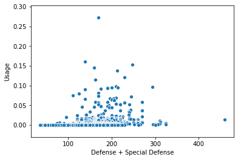

```python
ax1= sns.scatterplot(x= "Defense + Special Defense", y="Usage", data=pokemon_usage_dataframe_0)
```

Here is Defense + Special Defense vs Usage for players with an Elo between 1500 and 1695.

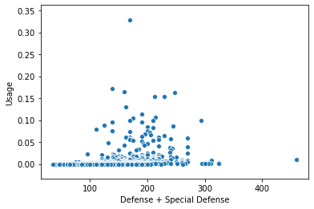

```python
ax1= sns.scatterplot(x= "Defense + Special Defense", y="Usage", data=pokemon_usage_dataframe_1500)
```

Here is Defense + Special Defense vs Usage for players with an Elo between 1695 and 1825.

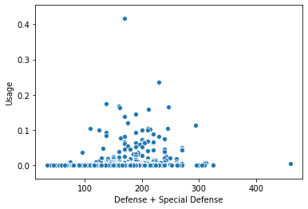

```python
ax1= sns.scatterplot(x= "Defense + Special Defense", y="Usage", data=pokemon_usage_dataframe_1695)
```

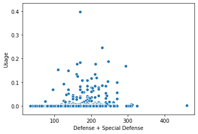

```python
ax1= sns.scatterplot(x= "Defense + Special Defense", y="Usage", data=pokemon_usage_dataframe_1825)
```

There isn't a linear trend visible in the scatter plots for Defense + Special Defense, but Pokemon wit Defense + Special Defense between 120 to 250 tend to be used more.

#### Stat Total vs Usage

Finally, let's generate scatter plots based off of Stat Total vs Usage for each tier of competitive Pokemon.

Here is Stat Total vs Usage for players with an Elo between 0 and 1500.

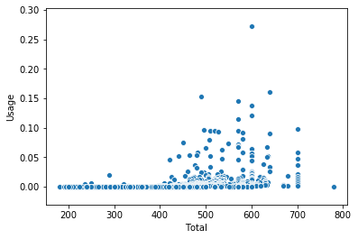

```python
ax1= sns.scatterplot(x= "Total", y="Usage", data=pokemon_usage_dataframe_0)
```

Here is Stat Total vs Usage for players with an Elo between 1500 and 1695.

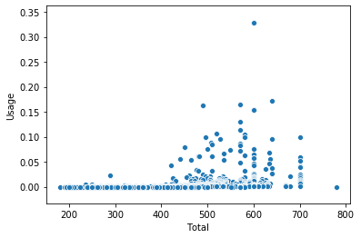

```python
ax1= sns.scatterplot(x= "Total", y="Usage", data=pokemon_usage_dataframe_1500)
```

Here is Stat Total vs Usage for players with an Elo between 1695 and 1825.

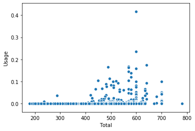

```python
ax1= sns.scatterplot(x= "Total", y="Usage", data=pokemon_usage_dataframe_1695)
```

Here is Stat Total vs Usage for players with an Elo greater than 1825

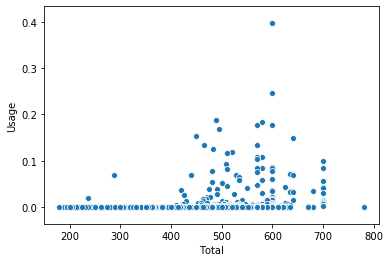

```python
ax1= sns.scatterplot(x= "Total", y="Usage", data=pokemon_usage_dataframe_1825)
```

Based off of the scatter plots for stat total vs usage it is easy to see that pokemon with higher stat totals tend to do be used more in competitive Pokemon than Pokemon with lower stat totals.

### Overall Analysis

From the scatter plots that I generated above I came with the following take aways. When only looking at one stat vs usage, Attack and Speed showed the most clear linear trend. When looking at the combinations of two different stats all of the permutations that I considered had a linear trend with the exception of Defense + Special Defense. Attack + Speed and Total have the most apparent trend when it comes to their relationship with usage.

This leads me to two possible conclusions as to the relationship between stats and usage:

1. The Attack and Speed scatter plot and the Special Attack and Speed scatter plot had a clear linear trend. Attack and Speed did have somewhat of a trend before being combined, but there was not as obvious as a trend visible for Special Attack. This could mean that Speed is an important factor when it comes to usage and that it complements high Attack and Special Attack well.
2. The other possible conclusion is that overall usage of Pokemon is mostly dependant on stat total rather than the values of individual stats. The reason for this conclusion is that generally when stats were combined in all cases except Defense + Special Defense usage increased. The stat total graph also reflected a similar trend as Pokemon with higher stat totals were generally used more than the other Pokemon disregarding Pokemon who are in the Ubers tier and are banned from Over Used.

[figure not shown]

### Heat Map

In order to perform this analysis, I will have to create a new Pandas Dataframe and will have to go through the tidying data process again albeit in a more abreviated manner.

```python
Top_52_Pokemon =["Alakazam-Mega", "Azumarill", "Blacephalon", "Celesteela", "Chansey", "Charizard-Mega-X", "Charizard-Mega-Y", "Clefable", "Diancie-Mega", "Excadrill", "Ferrothorn", "Garchomp", "Garchomp-Mega", "Gliscor", "Greninja", "Greninja-Ash", "Gyarados-Mega", "Hawlucha", "Heatran", "Jirachi", "Kartana", "Keldeo", "Kommo-o", "Kyurem-Black", "Landorus-Therian", "Latias-Mega", "Lopunny-Mega", "Magearna", "Magnezone", "Manaphy", "Mawile-Mega", "Medicham-Mega", "Pelipper", "Rotom-Wash", "Sableye-Mega", "Scizor-Mega", "Serperior", "Skarmory", "Swampert-Mega", "Tangrowth", "Tapu Bulu", "Tapu Fini", "Tapu Koko", "Tapu Lele", "Tornadus-Therian", "Toxapex", "Tyranitar", "Tyranitar-Mega", "Victini", "Volcarona", "Zapdos"]
```

Here I initialize a new dataframe starting with a column containing the names of the Pokemon in the list.

```python
heat_df = pandas.DataFrame(Top_52_Pokemon, columns = ['Pokemon'])
heat_df.head()
```

|  | Pokemon |
| --- | --- |
| 0 | Alakazam-Mega |
| 1 | Azumarill |
| 2 | Blacephalon |
| 3 | Celesteela |
| 4 | Chansey |

```python
usage_from_0=[]
usage_from_1500=[]
usage_from_1695=[]
usage_from_1825=[]

for pokemon in Top_52_Pokemon:
    exists=False
    for i in range(0,899):
        if pokemon_usage_dataframe_0["Pokemon"][i] == pokemon:
            exists=True
            usage_from_0.append(pokemon_usage_dataframe_0["Usage"][i])
    if not exists:
        print(pokemon)

for pokemon in Top_52_Pokemon:
    exists=False
    for i in range(0,899):
        if pokemon_usage_dataframe_1500["Pokemon"][i] == pokemon:
            exists=True
            usage_from_1500.append(pokemon_usage_dataframe_1500["Usage"][i])
    if not exists:
        print(pokemon)

for pokemon in Top_52_Pokemon:
    exists=False
    for i in range(0,899):
        if pokemon_usage_dataframe_1695["Pokemon"][i] == pokemon:
            exists=True
            usage_from_1695.append(pokemon_usage_dataframe_1695["Usage"][i])
    if not exists:
        print(pokemon)

for pokemon in Top_52_Pokemon:
    exists=False
    for i in range(0,899):
        if pokemon_usage_dataframe_1825["Pokemon"][i] == pokemon:
            exists=True
            usage_from_1825.append(pokemon_usage_dataframe_1825["Usage"][i])
    if not exists:
        print(pokemon)
```

I add the columns created in the code above to the heat_df dataframe.

```python
heat_df["Usage_0"]=usage_from_0
heat_df["Usage_1500"]=usage_from_1500
heat_df["Usage_1695"]=usage_from_1695
heat_df["Usage_1825"]=usage_from_1825
```

```python
heat_df.head()
```

|  | Pokemon | Usage_0 | Usage_1500 | Usage_1695 | Usage_1825 |
| --- | --- | --- | --- | --- | --- |
| 0 | Alakazam-Mega | 0.057204 | 0.057865 | 0.046784 | 0.035355 |
| 1 | Azumarill | 0.045727 | 0.042690 | 0.037852 | 0.037277 |
| 2 | Blacephalon | 0.045606 | 0.047431 | 0.047461 | 0.046521 |
| 3 | Celesteela | 0.067880 | 0.072704 | 0.065723 | 0.075276 |
| 4 | Chansey | 0.075114 | 0.080012 | 0.104378 | 0.153309 |

This dataframe looks well organized but it has to be further modified in oder for it to work well with creating Heat Map. I will create yet another dataframe using the one I created above to achieve this purpose.

```python
tier_0_lst=[]
tier_1500_lst=[]
tier_1695_lst=[]
tier_1825_lst=[]
for i in range(0,51):
    tier_0_lst.append("Usage_0")
    tier_1500_lst.append("Usage_1500")
    tier_1695_lst.append("Usage_1695")
    tier_1825_lst.append("Usage_1825")

total_tier_lst=[]
for element in tier_0_lst:
    total_tier_lst.append(element)
for element in  tier_1500_lst:
    total_tier_lst.append(element)
for element in  tier_1695_lst:
    total_tier_lst.append(element)
for element in  tier_1825_lst:
    total_tier_lst.append(element)

pokemon_lst=[]
for pokemon in heat_df["Pokemon"]:
    pokemon_lst.append(pokemon)
for pokemon in heat_df["Pokemon"]:
    pokemon_lst.append(pokemon)
for pokemon in heat_df["Pokemon"]:
    pokemon_lst.append(pokemon)
for pokemon in heat_df["Pokemon"]:
    pokemon_lst.append(pokemon)

useage_lst=[]
for useage in heat_df["Usage_0"]:
    useage_lst.append(useage)
for useage in heat_df["Usage_1500"]:
    useage_lst.append(useage)
for useage in heat_df["Usage_1695"]:
    useage_lst.append(useage)
for useage in heat_df["Usage_1825"]:
    useage_lst.append(useage)
```

Using the lists created above here is the dataframe needed.

```python
heat_map_df= pandas.DataFrame(pokemon_lst, columns = ['Pokemon'])
heat_map_df["Tier"]=total_tier_lst
heat_map_df["Useage"]=useage_lst
heat_map_df.head()
```

|  | Pokemon | Tier | Useage |
| --- | --- | --- | --- |
| 0 | Alakazam-Mega | Usage_0 | 0.057204 |
| 1 | Azumarill | Usage_0 | 0.045727 |
| 2 | Blacephalon | Usage_0 | 0.045606 |
| 3 | Celesteela | Usage_0 | 0.067880 |
| 4 | Chansey | Usage_0 | 0.075114 |

Using the dataframe created above, here is the heat map for the Usage of each of these Pokemon over across different levels of competitive play.

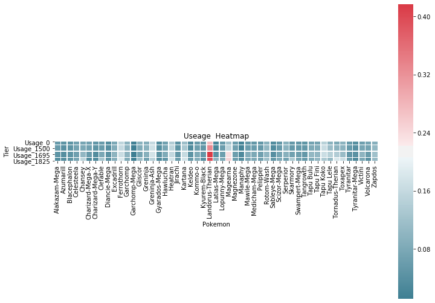

```python
cmap = sns.diverging_palette(220,10, as_cmap=True)
pivot = heat_map_df.pivot(index='Tier', columns="Pokemon", values='Useage')
f, ax = plt.subplots(figsize=(12,9))
plt.title("Useage " + ' Heatmap')
sns.heatmap(pivot, cmap=cmap, square=True, linewidths=.5, ax=ax)
```

# Predictions using Linear Regression

Now I will use SciKit Learn's Linear Regression tools to fit a linear regression model on the scatter plots I generated above.

```python
from sklearn.model_selection import train_test_split
from sklearn.linear_model import LinearRegression
from sklearn import metrics
```

I will focus solely on the 1825 and above Elo stats for this analysis as that is the most competitive tier.

### Attack vs Usage

Let's do linear regression on Attack vs Usage.

```python
X = pokemon_usage_dataframe_1825["Attack"].values.reshape(-1,1)
y = pokemon_usage_dataframe_1825["Usage"].values.reshape(-1,1)
```

```python
X_train, X_test, y_train, y_test = train_test_split(X, y, test_size=0.2, random_state=0)
```

```python
regressor = LinearRegression()
regressor.fit(X_train, y_train) #training the algorithm
```

```
LinearRegression(copy_X=True, fit_intercept=True, n_jobs=None, normalize=False)
```

```python
#To retrieve the intercept:
print(regressor.intercept_)
#For retrieving the slope:
print(regressor.coef_)
```

```
[-0.00425794]
[[0.00014206]]
```

```python
y_pred = regressor.predict(X_test)
```

```python
actual_vs_predicted = pandas.DataFrame({'Actual': y_test.flatten(), 'Predicted': y_pred.flatten()})
actual_vs_predicted.head()
```

|  | Actual | Predicted |
| --- | --- | --- |
| 0 | 5e-06 | 0.003555 |
| 1 | 0.0024891 | 0.007959 |
| 2 | 2.53e-05 | 0.002845 |
| 3 | 0.0688024 | 0.006396 |
| 4 | 6e-07 | 0.002277 |

There does not seem to be a very clear relationship between the Actual vs Predicted values when looking at Attack vs Usage.

Let's generate a bar graph for the Actual vs Predicted values for Attack vs Usage.

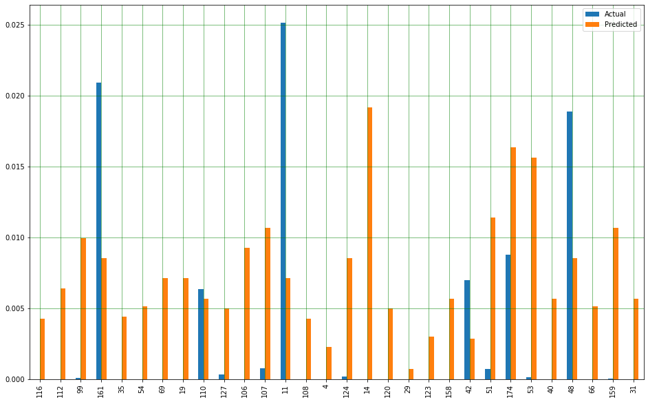

```python
bar = actual_vs_predicted.sample(n=30, random_state=1)
bar.plot(kind='bar',figsize=(16,10))
plt.grid(which='major', linestyle='-', linewidth='0.5', color='green')
plt.grid(which='minor', linestyle=':', linewidth='0.5', color='black')
plt.show()
```

This confirms that there is no clear linear relationship between the Attack stat of a Pokemon and its usage.

I suspect that individual stats will have no clear linear relationship like Attack so I will do linear regression using combinations of stats.

### Attack + Speed vs Usage

```python
X = pokemon_usage_dataframe_1825["Attack + Speed"].values.reshape(-1,1)
y = pokemon_usage_dataframe_1825["Usage"].values.reshape(-1,1)
X_train, X_test, y_train, y_test = train_test_split(X, y, test_size=0.4, random_state=0)
regressor = LinearRegression()
regressor.fit(X_train, y_train) #training the algorithm
y_pred = regressor.predict(X_test)
actual_vs_predicted = pandas.DataFrame({'Actual': y_test.flatten(), 'Predicted': y_pred.flatten()})
actual_vs_predicted.head()
```

|  | Actual | Predicted |
| --- | --- | --- |
| 0 | 5e-06 | 0.001297 |
| 1 | 0.0024891 | 0.006500 |
| 2 | 2.53e-05 | 0.003899 |
| 3 | 0.0688024 | 0.010025 |
| 4 | 6e-07 | -0.000213 |

Let's make a plot again of the Actual Values vs Predicted

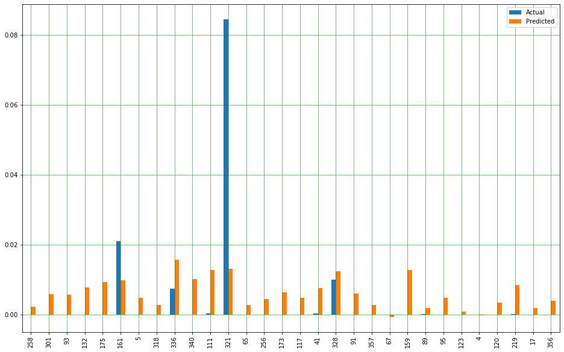

```python
bar = actual_vs_predicted.sample(n=30, random_state=1)
bar.plot(kind='bar',figsize=(16,10))
plt.grid(which='major', linestyle='-', linewidth='0.5', color='green')
plt.grid(which='minor', linestyle=':', linewidth='0.5', color='black')
plt.show()
```

### Special Attack + Speed vs Usage

```python
X = pokemon_usage_dataframe_1825["Special Attack + Speed"].values.reshape(-1,1)
y = pokemon_usage_dataframe_1825["Usage"].values.reshape(-1,1)
X_train, X_test, y_train, y_test = train_test_split(X, y, test_size=0.4, random_state=0)
regressor = LinearRegression()
regressor.fit(X_train, y_train) #training the algorithm
y_pred = regressor.predict(X_test)
actual_vs_predicted = pandas.DataFrame({'Actual': y_test.flatten(), 'Predicted': y_pred.flatten()})
actual_vs_predicted.head()
```

|  | Actual | Predicted |
| --- | --- | --- |
| 0 | 5e-06 | 0.006255 |
| 1 | 0.0024891 | 0.009029 |
| 2 | 2.53e-05 | 0.003799 |
| 3 | 0.0688024 | 0.010376 |
| 4 | 6e-07 | -0.000163 |

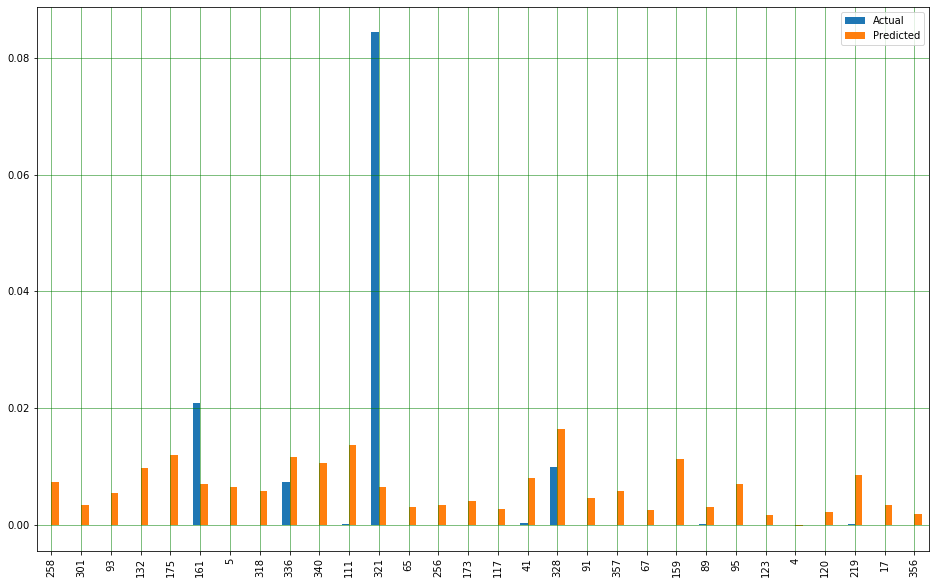

```python
bar = actual_vs_predicted.sample(n=30, random_state=1)
bar.plot(kind='bar',figsize=(16,10))
plt.grid(which='major', linestyle='-', linewidth='0.5', color='green')
plt.grid(which='minor', linestyle=':', linewidth='0.5', color='black')
plt.show()
```

### Attack + Special Attack vs Usage

```python
X = pokemon_usage_dataframe_1825["Attack + Special Attack"].values.reshape(-1,1)
y = pokemon_usage_dataframe_1825["Usage"].values.reshape(-1,1)
X_train, X_test, y_train, y_test = train_test_split(X, y, test_size=0.4, random_state=0)
regressor = LinearRegression()
regressor.fit(X_train, y_train) #training the algorithm
y_pred = regressor.predict(X_test)
actual_vs_predicted = pandas.DataFrame({'Actual': y_test.flatten(), 'Predicted': y_pred.flatten()})
actual_vs_predicted.head()
```

|  | Actual | Predicted |
| --- | --- | --- |
| 0 | 5e-06 | 0.007744 |
| 1 | 0.0024891 | 0.011072 |
| 2 | 2.53e-05 | 0.000897 |
| 3 | 0.0688024 | 0.006603 |
| 4 | 6e-07 | 0.000041 |

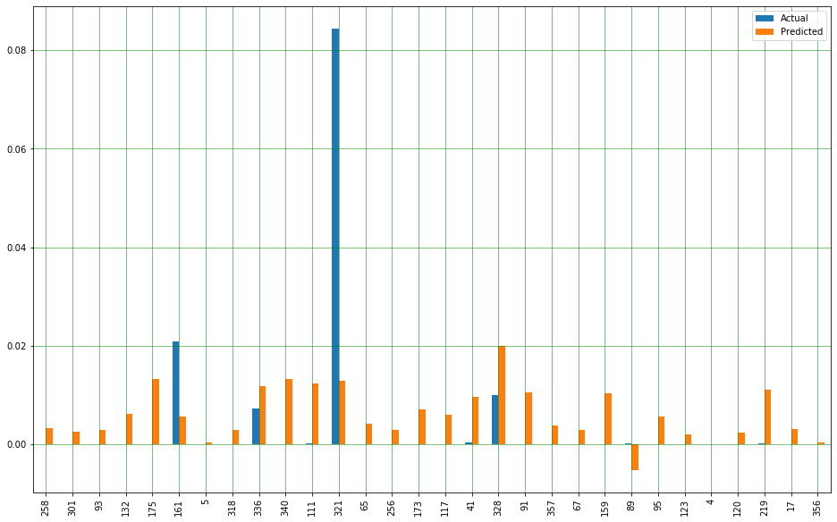

```python
bar = actual_vs_predicted.sample(n=30, random_state=1)
bar.plot(kind='bar',figsize=(16,10))
plt.grid(which='major', linestyle='-', linewidth='0.5', color='green')
plt.grid(which='minor', linestyle=':', linewidth='0.5', color='black')
plt.show()
```

### Defense + Special Defense

```python
X = pokemon_usage_dataframe_1825["Defense + Special Defense"].values.reshape(-1,1)
y = pokemon_usage_dataframe_1825["Usage"].values.reshape(-1,1)
X_train, X_test, y_train, y_test = train_test_split(X, y, test_size=0.4, random_state=0)
regressor = LinearRegression()
regressor.fit(X_train, y_train) #training the algorithm
y_pred = regressor.predict(X_test)
actual_vs_predicted = pandas.DataFrame({'Actual': y_test.flatten(), 'Predicted': y_pred.flatten()})
actual_vs_predicted.head()
```

|  | Actual | Predicted |
| --- | --- | --- |
| 0 | 5e-06 | 0.009964 |
| 1 | 0.0024891 | 0.010920 |
| 2 | 2.53e-05 | 0.004015 |
| 3 | 0.0688024 | 0.011026 |
| 4 | 6e-07 | -0.000765 |

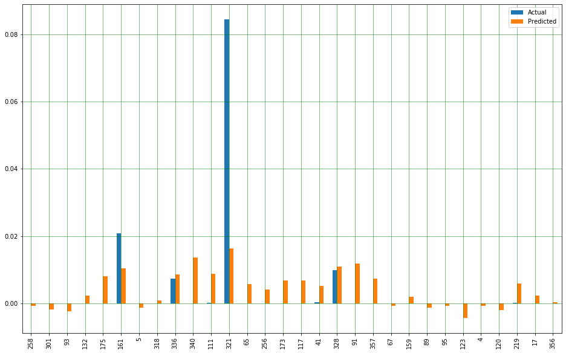

```python
bar = actual_vs_predicted.sample(n=30, random_state=1)
bar.plot(kind='bar',figsize=(16,10))
plt.grid(which='major', linestyle='-', linewidth='0.5', color='green')
plt.grid(which='minor', linestyle=':', linewidth='0.5', color='black')
plt.show()
```

### Total

```python
X = pokemon_usage_dataframe_1825["Total"].values.reshape(-1,1)
y = pokemon_usage_dataframe_1825["Usage"].values.reshape(-1,1)
X_train, X_test, y_train, y_test = train_test_split(X, y, test_size=0.4, random_state=0)
regressor = LinearRegression()
regressor.fit(X_train, y_train) #training the algorithm
y_pred = regressor.predict(X_test)
actual_vs_predicted = pandas.DataFrame({'Actual': y_test.flatten(), 'Predicted': y_pred.flatten()})
actual_vs_predicted.head()
```

|  | Actual | Predicted |
| --- | --- | --- |
| 0 | 5e-06 | 0.009574 |
| 1 | 0.0024891 | 0.011964 |
| 2 | 2.53e-05 | 0.000791 |
| 3 | 0.0688024 | 0.011853 |
| 4 | 6e-07 | -0.005546 |

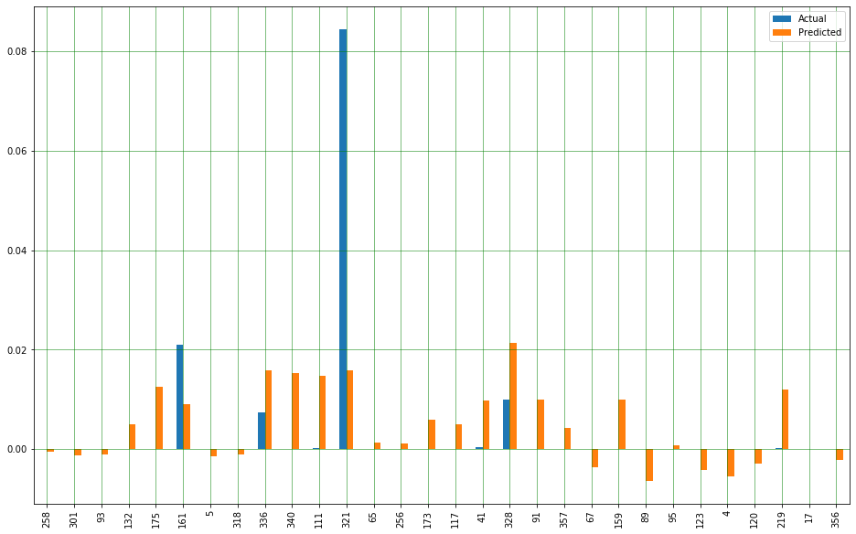

```python
bar = actual_vs_predicted.sample(n=30, random_state=1)
bar.plot(kind='bar',figsize=(16,10))
plt.grid(which='major', linestyle='-', linewidth='0.5', color='green')
plt.grid(which='minor', linestyle=':', linewidth='0.5', color='black')
plt.show()
```

Even for the combinations of stats there is not a clear model to predict the Usage based off of stats.

Even though through linear regression I was not able to successfully fit linear regression to make accurate predictions, it does not mean that there is no relationship between stats and usage. There could be a relationship between stats and usage, just not a linear relationship.

[figure not shown]

# Conclusions

The main purpose of this tutorial was to analyze data of Pokemon stats and usage of those Pokemon to give Pokemon players a good idea as which Pokemon are good to use and which Pokemon are not really good to use. Making predictions was a part of this tutorial but it was not a main focus of the tutorial. Making the pie chart, the scatter plots, and the heat map were a very important part of this tutorial and they did give us a few takeaways. Landorus-Therian is by far the most used Pokemon in Generation 7 Over Used followed by Magearna and Pokemon with higher Attack and Speed stat totals and Special Attack and Speed stat totals tend to have higher usage than other combinations of stats meaning that those combinations complement each other well. In future tutorials, I would like to do a more general analysis taking into acount more factors than only stats. I would add focus to affect of abilities, Pokemon types, movepool and other factors.

From this tutorial, I hope readers are better able to understand the way competitive Pokemon battles work and how to attempt to build affective teams if they were to choose to delve into the competitive scene. If you are interested in playing competitive Pokemon, [Pokemon Showdown](https://pokemonshowdown.com/) is a great place to get started. You can build competitive Pokemon teams and battle with them very easily without having to purchase any of the Pokemon games. If you are really interested in Pokemon, you can purchase a copy of Pokemon Sword or Pokemon Shield and battle players online there. Pokemon Sword and Shield are the most easy to access competitive Pokemon games so far so it is a great place to start off.